# Tech Relationship Analysis

# Plot

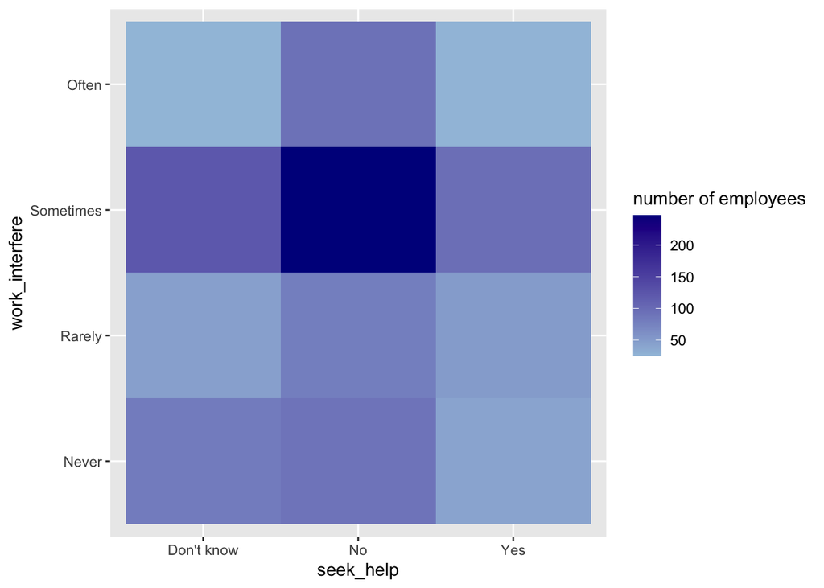

# Analysis

The heatmap was created based on data from the OSMI 2014 Mental Health in Tech Survey. There were 995 observations collected and plotted based on the answers to the following questions:

- work_interfere: If you have a mental health condition, do you feel that it interferes with your work?
- seek_help: Does your employer provide resources to learn more about mental health as part of an employee wellness program?

It is not specified in the survey what their measure for a mental health condition is nor what is explicitly meant by “mental health as part of an employee wellness program,” meaning respondents may have different approaches to this question. Out of the 995 respondents, 465 indicated that sometimes their mental health condition does interfere with their work, suggesting having resources available is necessary. However, a high number of respondents said that their employer did not provide resources about mental health. In total, 509 people responded that that their workplace did not have provide mental health resources as part of a wellness program.

Beyond the number of employees that use resources from wellness programs, a stigma is bound to exist for those that might seek out help if employers do not make the effort to make help widely known and available. The fact that many of the respondents that indicated mental health sometimes interferes with their work also answered a definitive “no” that mental health resources through programs were not available could suggest that they tried to seek help from their company to no avail. These types of answers leave lots of other questions to unpack such as what specific ways mental health affects the workplace, what types of resources should employers be expected to provide, and what this information implies for a national workforce.